# Video Game Sales Revisualization

Phankawee Mukdaprakorn

### Original

The original data visualisation selected for the assignment was as follows:

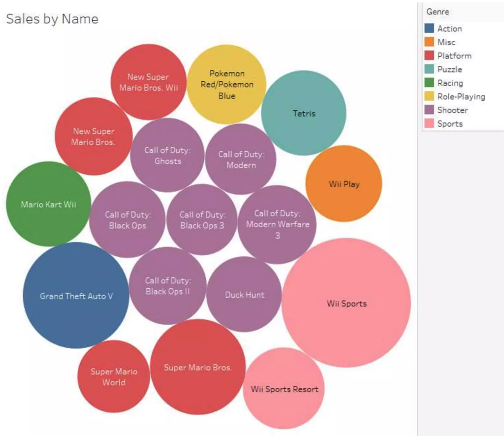

*Source: Video Games Sales Analysis (Vijayvergia, 2017).*

The objective and audience of the original data visualisation chosen can be summarised as follows:

**Objective**

This visualization provides a broad summary of video games sales by name. It visually shows the sales volume using bubble sizes, with different colors indicating each game’s genre. This helps viewers quickly see which games have higher sales and how they compare to others across various genres.

**Target Audience**

The target audience for this bubble chart includes **video game analysts**, **developers**, and **business stakeholders** who would likely encounter this visualization in a **Market Intelligence Annual Report** or a **Gaming Industry Newsletter**. They use the visualization to quickly identify top-selling games and popular genres, aiding in market analysis, product development, and strategic decision-making.

### Critique

The visualization chosen had the following three main issues:

- **Lack of Clear Ranking or Comparison** - The visualization relies on bubble size to indicate sales volume, which can make it difficult to compare and rank video games accurately. Human visual system is less precise when interpreting size compared to simpler elements like length or position (Baglin 2024). A more effective approach might be using bar charts or line plots, where values can be more directly compared based on position or length, which are visually easier to interpret.
- **Lack of Regional Sales Breakdown** - The visualization only shows global sales, which is a missed opportunity to provide insights into sales performance in different regions. Understanding sales by region can be important for game developers and businesses to make strategic decisions about market-specific game releases and promotions.
- **Genre Color Coding and Grouping** - While the visualization uses colors to represent different game genres, the choice of colors and the number of categories may not be good. The visual distinction between some colors might be too subtle for clear interpretation, especially for users with colorblindness problems. Additionally, some genres, such as Puzzle or Misc and some other groups, could be grouped together to reduce the number of categories and make the visualization less cluttered. Too many categories in the legend can overwhelm the user, leading to confusion than clarity.

### Code

The following code was used to fix the issues identified in the original.

```r
library(ggplot2)
library(tidyr)
library(dplyr)
library(tidyverse)
library(extrafont)

vgsales <- read_csv("https://raw.githubusercontent.com/xzhang0529/Explore-Video-Games-Sales/master/dataset/vgsales.csv")
str(vgsales)
```

```
## spc_tbl_ [16,598 × 11] (S3: spec_tbl_df/tbl_df/tbl/data.frame)
##  $ Rank        : num [1:16598] 1 2 3 4 5 6 7 8 9 10 ...
##  $ Name        : chr [1:16598] "Wii Sports" "Super Mario Bros." "Mario Kart Wii" "Wii Sports Resort" ...
##  $ Platform    : chr [1:16598] "Wii" "NES" "Wii" "Wii" ...
##  $ Year        : chr [1:16598] "2006" "1985" "2008" "2009" ...
##  $ Genre       : chr [1:16598] "Sports" "Platform" "Racing" "Sports" ...
##  $ Publisher   : chr [1:16598] "Nintendo" "Nintendo" "Nintendo" "Nintendo" ...
##  $ NA_Sales    : num [1:16598] 41.5 29.1 15.8 15.8 11.3 ...
##  $ EU_Sales    : num [1:16598] 29.02 3.58 12.88 11.01 8.89 ...
##  $ JP_Sales    : num [1:16598] 3.77 6.81 3.79 3.28 10.22 ...
##  $ Other_Sales : num [1:16598] 8.46 0.77 3.31 2.96 1 0.58 2.9 2.85 2.26 0.47 ...
##  $ Global_Sales: num [1:16598] 82.7 40.2 35.8 33 31.4 ...
##  - attr(*, "spec")=
##   .. cols(
##   ..   Rank = col_double(),
##   ..   Name = col_character(),
##   ..   Platform = col_character(),
##   ..   Year = col_character(),
##   ..   Genre = col_character(),
##   ..   Publisher = col_character(),
##   ..   NA_Sales = col_double(),
##   ..   EU_Sales = col_double(),
##   ..   JP_Sales = col_double(),
##   ..   Other_Sales = col_double(),
##   ..   Global_Sales = col_double()
##   .. )
##  - attr(*, "problems")=<externalptr>
```

```r
vgsales$Platform <- as.factor(vgsales$Platform)
vgsales$Year <- as.factor(vgsales$Year)
vgsales$Genre <- as.factor(vgsales$Genre)
vgsales$Publisher <- as.factor(vgsales$Publisher)
head(vgsales)
```

```
## # A tibble: 6 × 11
##    Rank Name           Platform Year  Genre Publisher NA_Sales EU_Sales JP_Sales
##   <dbl> <chr>          <fct>    <fct> <fct> <fct>        <dbl>    <dbl>    <dbl>
## 1     1 Wii Sports     Wii      2006  Spor… Nintendo      41.5    29.0      3.77
## 2     2 Super Mario B… NES      1985  Plat… Nintendo      29.1     3.58     6.81
## 3     3 Mario Kart Wii Wii      2008  Raci… Nintendo      15.8    12.9      3.79
## 4     4 Wii Sports Re… Wii      2009  Spor… Nintendo      15.8    11.0      3.28
## 5     5 Pokemon Red/P… GB       1996  Role… Nintendo      11.3     8.89    10.2
## 6     6 Tetris         GB       1989  Puzz… Nintendo      23.2     2.26     4.22
## # ℹ 2 more variables: Other_Sales <dbl>, Global_Sales <dbl>
```

```r
# Regroup the genres 'Puzzle', 'Misc', 'Role-Playing', 'Simulation' to 'Other*'
vgsales_top_30 <- vgsales %>%
  mutate(Genre = recode(Genre,
                        "Puzzle" = "Other*",
                        "Misc" = "Other*",
                        "Role-Playing" = "Other*",
                        "Simulation" = "Other*")) %>%
  group_by(Name, Publisher, Genre) %>%
  summarise(GlobalSales = sum(Global_Sales),
            NASales = sum(NA_Sales),
            EUSales = sum(EU_Sales),
            JPSales = sum(JP_Sales),
            OtherSales = sum(Other_Sales),
            Count = n(),
            .groups = 'drop') %>%
  arrange(desc(GlobalSales)) %>%
  head(30)

# Reshape data to long format for easier plotting
vgsales_top_30_long <- gather(vgsales_top_30, key = "Sales Region", value = "Sales", GlobalSales:OtherSales)

# Set factor levels for game names (to preserve order in plot)
vgsales_top_30_long$Name <- factor(vgsales_top_30_long$Name,
                                   levels = unique(vgsales_top_30$Name[order(vgsales_top_30$GlobalSales)]))

# Set factor levels for sales regions
vgsales_top_30_long$`Sales Region` <- factor(vgsales_top_30_long$`Sales Region`,
                                             levels = c("GlobalSales", "NASales", "EUSales", "JPSales", "OtherSales"),
                                             labels = c("Global Sales", "North America", "Europe", "Japan", "Other Regions"))

# Rank the games separately for each region to be put in the visualization
vgsales_top_30_long$Rank <- c(rank(-vgsales_top_30$GlobalSales, ties.method = "min"),
                              rank(-vgsales_top_30$NASales, ties.method = "min"),
                              rank(-vgsales_top_30$EUSales, ties.method = "min"),
                              rank(-vgsales_top_30$JPSales, ties.method = "min"),
                              rank(-vgsales_top_30$OtherSales, ties.method = "min"))

# Build the barplot
p <- ggplot(vgsales_top_30_long, aes(x = Name, y = Sales, fill = Genre)) +
  geom_bar(stat = "identity") +
  labs(title = "Top 30 Highest Selling Video Games:\nA Global and Regional Perspective (1980-2020) (Million USD)",
       subtitle = "North America leads regional sales, while Japan remains a niche market for global bestsellers",
       caption = "Source: Video Games Sales Analysis (Vijayvergia, 2017) - https://www.slideshare.net/slideshow/video-game-sales-analysis-84181197/84181197
       Data Source: Explore-Video-Games-Sales (xzhang0529, 2018) - https://raw.githubusercontent.com/xzhang0529/Explore-Video-Games-Sales/master/dataset/vgsales.csv
       *Other genres are Puzzle, Role-Playing, Simulations, and Misc") +
  theme(text = element_text(family = "Palatino"),
        plot.title = element_text(size = 10, face = "bold"),
        plot.subtitle = element_text(size = 8),
        plot.caption = element_text(size = 6),
        axis.text.y = element_text(size = 5),
        axis.text.x = element_text(size = 5),
        axis.title.x = element_blank(),
        axis.title.y = element_blank(),
        axis.ticks = element_line(linewidth = 0.2),
        legend.position = "bottom",
        legend.title = element_text(size = 5, face = "bold"),
        legend.text = element_text(size = 5),
        strip.text = element_text(size = 5.5, face = "bold")) +
  coord_flip()

# Calculate the mean sales for each region to include in facet headers
Regional_mean <- vgsales_top_30_long %>%
  group_by(`Sales Region`) %>%
  summarise(mean_val = round(mean(Sales), 2))

# Create custom labels for the facets including the mean value (mu)
facet_labels <- setNames(
  paste0(Regional_mean$`Sales Region`, " (\u03bc = ", Regional_mean$mean_val, ")"),
  Regional_mean$`Sales Region`
)

# Define colors for the palette (colorblind-friendly)
bg_color <- "#EFF1F0"
col_palete <- c("#800020", "#708090", "#CFC29F", "#96A8A1", "#ADD8E6", "#36454F")

# Update the plot with new facets and ranking labels
p <- p +
  facet_grid(~`Sales Region`, labeller = as_labeller(facet_labels)) +
  geom_text(aes(label = Rank, y = 0),  # Add ranking text to the plot
            hjust = "top", size = 1.3) +
  scale_fill_manual(values = col_palete, guide = guide_legend(nrow = 1)) +
  theme(plot.background = element_rect(fill = bg_color),
        panel.background = element_rect(fill = bg_color),
        legend.background = element_rect(fill = bg_color))
```

The following plot fixes the main issues in the original.

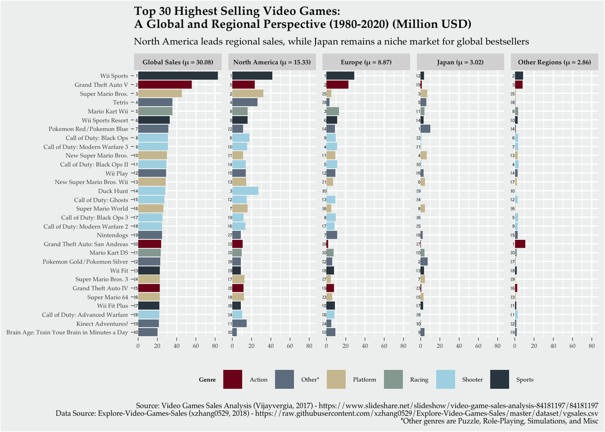

## References

The reference to the original data visualisation choose, the data source(s) used for the reconstruction and any other sources used for this assignment are as follows:

- Baglin, J. (2024). *Data Visualisation Chapter 3: Visual Perception and Colour* [Website]. Royal Melbourne Institute of Technology.
- Baglin, J. (2024). *Data Visualisation Chapter 6: Multivariate Strategies* [PDF file]. Royal Melbourne Institute of Techonology.
- Bobbitt, Z. (2023). R: A Complete Guide to ties.method in rank Function. Statology. https://www.statology.org/r-rank-ties-method/
- *ggplot2 3.5.0: Legends*. (2024). https://www.tidyverse.org/blog/2024/02/ggplot2-3-5-0-legends/
- Vijayvergia, A. (2017). Video game sales analysis. *slideshare*. https://www.slideshare.net/slideshow/video-game-sales-analysis-84181197/84181197#4
- xzhang0529. (2018). *vgsales* (https://raw.githubusercontent.com/xzhang0529/Explore-Video-Games-Sales/master/dataset/vgsales.csv